# Data munging and Figure 1 preparation

# AUC across Expression Cutoffs

Since the experimental outcomes are continuous (not binary), expression can be defined via many different thresholds. To assess the degree of predictive performance, the AUC of the ROCs for each one of these cutoffs is plotted.

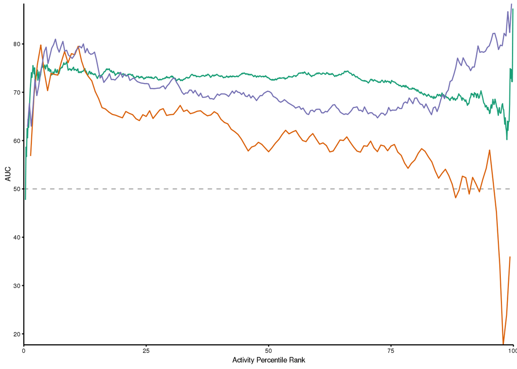

```r
# all possible cutoffs with AUCs
p1_ecoli_auc <- ecoli_auc %>%
    ungroup %>%
    mutate(cterm = factor(cterm, levels = c("in", "out", "fluman"),
                          ordered = TRUE)) %>%
    ggplot(aes(x = outcome_percentile, color = cterm)) +
    geom_hline(aes(yintercept = .5), linetype = "dashed", color = "darkgrey") +
    geom_line(aes(y = auc)) +
    scale_y_continuous(expand = c(0L, 0L), breaks = seq(0, 1, .1),
                       labels = function(x) x*100) +
    scale_x_continuous(expand = c(0L, 0L), breaks = seq(0L, 100L, 25L),
                       limit = c(0, 100)) +
    ylab("AUC") +
    xlab("Activity Percentile Rank") +
    scale_color_manual(values = brewer.pal(3L, "Dark2")) +
    theme(legend.position = "None")

p1_ecoli_auc
```

## Compile the plots for the training data figure

This block compiles the figures generated above into the preliminary version of Figure 1. Some minor adjustments were made after the fact using Adobe Illustrator, e.g. removing clipping masks, fixing font faces.

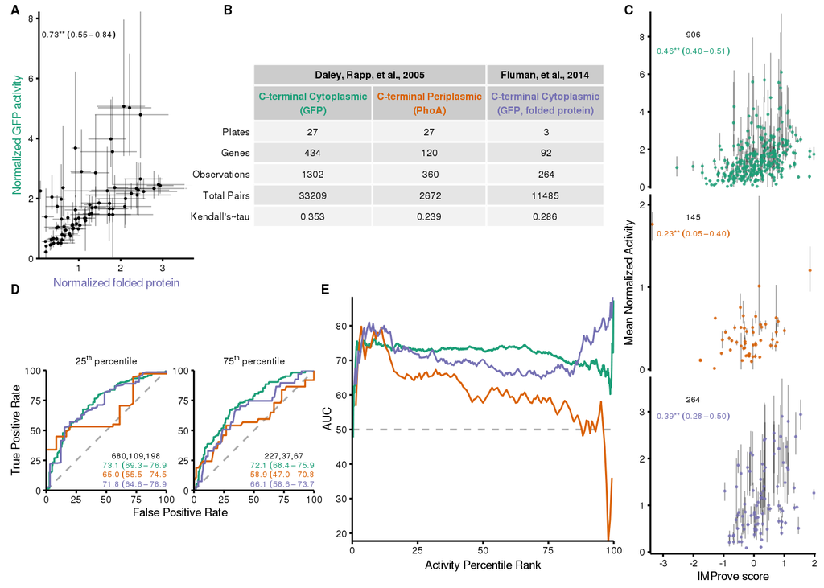

```r
p1_main <- ggdraw() +
    draw_plot(p1_daley_fluman, x = .0, y = .5, width = .23, height = 0.48) +
    draw_plot(p1_table, x = .21, y = 0.51, width = 1 - .47, height = 0.48) +
    draw_plot(p1_ecoli_xy, x = .75, y = 0, width = .24, height = .98) +
    draw_plot(plot_grid(p1_ecoli_roc, p1_ecoli_auc,
                        nrow = 1L, rel_widths = c(1L, 1L)),
              x = 0, y = 0, width = .75, height = .5) +
    draw_plot_label(LETTERS[1:5],
                    c(0, 0.26, .75, 0, 0.38), c(1, 1, 1, 0.52, 0.52), size = 8L)
if (write_out) {
    save_plot(filename = "plots/fig1_w_panels.pdf",
              plot = p1_main,
              base_width = uconv(183L, "mm", "in", "Length"),
              base_height = 3L)
}

ggdraw(p1_main)
```

## Save environment for future reference

No variables need to be kept. Since bootstraps are recorded to file at the time they are calculated.

## look at variability due to normalization

```r
var_x_y <- function(mean_x, mean_y, var_x, var_y, cov_x_y)
    (mean_x / mean_y) ^ 2 * (
        (var_x / mean_x) ^ 2 + (var_y / mean_y) ^ 2 -
        2 * (cov_x_y / (mean_x * mean_y))
    )

daley_variation <- training_env$daley_outcomes %>%
    filter(cterm != "fluman", grepl("Val", measurement)) %>%
    separate(grouping, c("Day")) %>%
    left_join(training_env$control_outcomes) %>%
    mutate(outcome_raw = outcome*(control - background)) %>%
    group_by(id) %>%
    summarize(mean_id = mean(outcome_raw),
              mean_ctrl = mean(control),
              var_id = var(outcome_raw),
              var_ctrl = var(control),
              cov_id_ctrl = cov(outcome_raw, control)) %>%
    ungroup %>%
    mutate(var_id_ctrl = var_x_y(mean_id, mean_ctrl,
                                 var_id, var_ctrl, cov_id_ctrl),
           var_id_less = var_id < var_id_ctrl,
           var_ctrl_less = var_ctrl < var_id_ctrl)
```

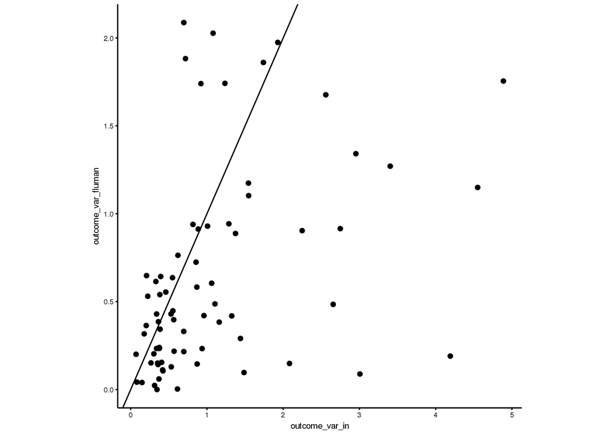

```r
ggplot(ecoli_daley_fluman) +
    geom_point(aes(outcome_var_in, outcome_var_fluman)) +
    geom_abline(slope = 1) +
    theme(aspect.ratio = 1)
```

```r
table(ecoli_daley_fluman$outcome_var_in > ecoli_daley_fluman$outcome_var_fluman)
```

```
##
## FALSE  TRUE
##    22    51
```

```r
# FALSE  TRUE
#    22    51
#
# 22/51
# [1] 0.4313725
```